# RMD con la Base oficial - Grupo 3

# Limpieza de bases de datos de desigualdad de ingresos e índice de corrupción (Isaura Sánchez)

# Librerias

```r
library(htmltab)
library(stringr)
library(readr)
library(rio)
```

# Importar data para la variable desigualdad de ingresos (GINI)

```r
linkgini = "https://github.com/isaurayamile/TRABAJO-ESTADISTICA/raw/master/GINI%202016%20DATA%20INDEX.xlsx"
GINI = import(linkgini)
```

# Limpieza para la variable desigualdad de ingresos (GINI)

```r
names(GINI)
```

```
## [1] "Países"    "GINI 2016" "decimales"
```

```r
str(GINI)
```

```
## 'data.frame':    106 obs. of  3 variables:
##  $ Países   : chr  "Algeria" "Argentina" "Armenia" "Azerbaijan" ...
##  $ GINI 2016: num  35.8 41.2 33.6 26.6 37.5 32.4 47.8 37.4 44 33 ...
##  $ decimales: num  0.358 0.412 0.336 0.266 0.375 0.324 0.478 0.374 0.44 0.33 ...
```

```r
GINI [,3] = NULL

#OBSERVAR DATA
summary(GINI)
```

```
##     Países            GINI 2016
##  Length:106         Min.   :25.40
##  Class :character   1st Qu.:35.30
##  Mode  :character   Median :37.85
##                     Mean   :39.61
##                     3rd Qu.:43.92
##                     Max.   :63.00
```

```r
#RECODIFICACIÓN DE VARIABLES

GINI$`GINI 2016`=as.numeric(GINI$`GINI 2016`)

#ORDENAR DATA

GINI$num2=c(1:106)
GINI$num2=as.numeric(GINI$num2)
row.names(GINI)=GINI$num2
GINI$num2=NULL

#Ver casos duplicados e incompletos
GINI[duplicated(GINI$Pais),]
```

```
## [1] Países    GINI 2016
## <0 rows> (or 0-length row.names)
```

```r
GINI[!complete.cases(GINI),]
```

```
## [1] Países    GINI 2016
## <0 rows> (or 0-length row.names)
```

```r
names(GINI)=c("Pais","GINI2016")
```

# Importar data para la variable de Accountability

```r
linkAccountability = "https://github.com/isaurayamile/TRABAJO-ESTADISTICA/raw/master/Data_Extract_From_Worldwide_Governance_Indicators%20(1).xlsx"
Account = import(linkAccountability)
```

# Limpieza para la variable de Accountability

```r
names(Account)
```

```
## [1] "Country Name"  "Country Code"  "Series Name"   "Series Code"
## [5] "2016 [YR2016]"
```

```r
str(Account)
```

```
## 'data.frame':    219 obs. of  5 variables:
##  $ Country Name : chr  "Afghanistan" "Albania" "Algeria" "American Samoa" ...
##  $ Country Code : chr  "AFG" "ALB" "DZA" "ASM" ...
##  $ Series Name  : chr  "Voice and Accountability: Estimate" "Voice and Accountability: Estimate" "Voice and Accountability: Estimate" "Voice and Accountability: Estimate" ...
##  $ Series Code  : chr  "VA.EST" "VA.EST" "VA.EST" "VA.EST" ...
##  $ 2016 [YR2016]: chr  "-1.039843" "0.1699492" "-0.8631691" ".." ...
```

```r
Account [,c(2:4)] = NULL #ELIMINAR COLUMNAS
Account= Account[-c(215:219),]#ELIMINAR FILAS
names(Account) = c("Pais","Account2016")  #CAMBIO DE NOMBRES
summary(Account)
```

```
##      Pais           Account2016
##  Length:214         Length:214
##  Class :character   Class :character
##  Mode  :character   Mode  :character
```

```r
#Cambio de nombres para estandarizarlos y poder hacer el merge
Account[Account$Pais=="Czechia",'Pais']="Czech Republic"
Account[Account$Pais=="Hong Kong SAR, China",'Pais']="Hong Kong"
Account[Account$Pais=="Iran, Islamic Rep.",'Pais']="Iran"
Account[Account$Pais=="Guinea-Bissau",'Pais']="Guinea Bissau"
Account[Account$Pais=="Lao PDR",'Pais']="Laos"
Account[Account$Pais=="Korea, Dem. People’s Rep.",'Pais']="Korea, North"
Account[Account$Pais=="Korea, Rep.",'Pais']="Korea, South"
Account[Account$Pais=="United States",'Pais']="United States of America"
Account[Account$Pais=="Bahamas, The",'Pais']="Bahamas"
Account[Account$Pais=="Congo, Dem. Rep.",'Pais']="Democratic Republic of the Congo"
Account[Account$Pais=="Congo, Rep.",'Pais']="Congo"
Account[Account$Pais=="Egypt, Arab Rep.",'Pais']="Egypt"
Account[Account$Pais=="Russian Federation",'Pais']="Russia"
Account[Account$Pais=="Kyrgyz Republic",'Pais']="Kyrgyzstan"
Account[Account$Pais=="Gambia, The",'Pais']="Gambia"
Account[Account$Pais=="Slovak Republic",'Pais']="Slovakia"
Account[Account$Pais=="St. Lucia",'Pais']="Saint Lucia"
Account[Account$Pais=="St. Vincent and the Grenadines",'Pais']="Saint Vincent and the Grenadines"
Account[Account$Pais=="Yemen, Rep.",'Pais']="Yemen"
Account[Account$Pais=="Venezuela, RB",'Pais']="Venezuela"
Account[Account$Pais=="Syrian Arab Republic",'Pais']="Syria"
Account[Account$Pais=="Taiwan, China",'Pais']="Taiwan"
Account[Account$Pais=="Taiwan, China",'Pais']="Taiwan"
#RECODIFICACIÓN DE VARIABLES
Account$Account2016=as.numeric(Account$Account2016)
#ORDENAR DATA
Account$num3=c(1:214)
Account$num3=as.numeric(Account$num3)
row.names(Account)=Account$num3
Account$num3=NULL
Account= Account[-159,] #fila para eliminar
Account$num3=c(1:213) #volver a ordenar (este paso se puede omitir)
Account$num3=as.numeric(Account$num3)
row.names(Account)=Account$num3
Account$num3=NULL
#Ver casos duplicados e incompletos
Account[duplicated(Account$Pais),]
```

```
## [1] Pais        Account2016
## <0 rows> (or 0-length row.names)
```

```r
Account[!complete.cases(Account),]
```

```
##                      Pais Account2016
## 4          American Samoa          NA
## 7                Anguilla          NA
## 23                Bermuda          NA
## 46           Cook Islands          NA
## 77                   Guam          NA
## 123            Martinique          NA
## 139  Netherlands Antilles          NA
## 144                  Niue          NA
## 209 Virgin Islands (U.S.)          NA
```

```r
summary(Account)
```

```
##      Pais            Account2016
##  Length:213         Min.   :-2.1804
##  Class :character   1st Qu.:-0.7651
##  Mode  :character   Median : 0.1390
##                     Mean   : 0.0000
##                     3rd Qu.: 0.8639
##                     Max.   : 1.6643
##                     NA's   :9
```

# Importar data para la variable dependiente: IPC

```r
linkIPC = "https://github.com/isaurayamile/TRABAJO-ESTADISTICA/raw/master/CPI2019.xlsx"
ICP = import(linkIPC)
```

```
## * `` -> ...2
## * `` -> ...3
## * `` -> ...4
## * `` -> ...5
## * `` -> ...6
## * ...
```

```r
names(ICP)
```

```
##  [1] "Corruption Perceptions Index 2019: Score timeseries since 2012"
##  [2] "...2"
##  [3] "...3"
##  [4] "...4"
##  [5] "...5"
##  [6] "...6"
##  [7] "...7"
##  [8] "...8"
##  [9] "...9"
## [10] "...10"
## [11] "...11"
## [12] "...12"
## [13] "...13"
## [14] "...14"
## [15] "...15"
## [16] "...16"
## [17] "...17"
## [18] "...18"
## [19] "...19"
## [20] "...20"
## [21] "...21"
## [22] "...22"
## [23] "...23"
## [24] "...24"
## [25] "...25"
## [26] "...26"
## [27] "...27"
## [28] "...28"
## [29] "...29"
## [30] "...30"
```

```r
str(ICP)
```

```
## 'data.frame':    182 obs. of  30 variables:
##  $ Corruption Perceptions Index 2019: Score timeseries since 2012: chr  NA "Country" "New Zealand" "Denmark" ...
##  $ ...2                                                          : chr  NA "ISO3" "NZL" "DNK" ...
##  $ ...3                                                          : chr  NA "Region" "AP" "WE/EU" ...
##  $ ...4                                                          : chr  NA "CPI score 2019" "87" "87" ...
##  $ ...5                                                          : chr  NA "Rank 2019" "1" "1" ...
##  $ ...6                                                          : chr  NA "Sources 2019" "8" "8" ...
##  $ ...7                                                          : chr  NA "Standard error 2019" "2.2864900000000001" "2.5424739999999999" ...
##  $ ...8                                                          : chr  NA "CPI score 2018" "87" "88" ...
##  $ ...9                                                          : chr  NA "Rank 2018" "2" "1" ...
##  $ ...10                                                         : chr  NA "Sources 2018" "8" "8" ...
##  $ ...11                                                         : chr  NA "Standard error 2018" "2.44" "2.63" ...
##  $ ...12                                                         : chr  NA "CPI score 2017" "89" "88" ...
##  $ ...13                                                         : chr  NA "Rank 2017" "1" "2" ...
##  $ ...14                                                         : chr  NA "Sources 2017" "8" "8" ...
```

[output cut: 16 more lines]

```r
#LIMPIEZA DE DATA DE LA VARIABLE DEPENDIENTE
ICP [,c(2:15)] = NULL  #ELIMINAR COLUMNAS
ICP [,c(3:16)] = NULL
ICP= ICP [-(1:2),] #ELIMINAR FILAS
#ORDENAR DATA
ICP$num=c(1:180)
ICP$num=as.numeric(ICP$num)
row.names(ICP)=ICP$num
ICP$num=NULL
#ELIMINAR FILAS
ICP= ICP[-27,]
ICP= ICP[-64,]
ICP= ICP[-111,]
ICP= ICP[-171,]
names(ICP) = c("Pais","CPI2016")  #CAMBIO DE NOMBRES
#VER CASOS DUPLICADOS E INCOMPLETOS
ICP[duplicated(ICP$Pais),]
```

```
## [1] Pais    CPI2016
## <0 rows> (or 0-length row.names)
```

```r
ICP[!complete.cases(ICP),]
```

```
## [1] Pais    CPI2016
## <0 rows> (or 0-length row.names)
```

```r
#ORDENAR DATA
ICP$num=c(1:176)
ICP$num=as.numeric(ICP$num)
row.names(ICP)=ICP$num
ICP$num=NULL
```

# MERGE

##Estos merge se utilizaron para poder estandarizar los nombres de los páises de las variables independientes con la variable dependiente

# Merge de ICP con GINI

```r
names(ICP)
```

```
## [1] "Pais"    "CPI2016"
```

```r
names(GINI)
```

```
## [1] "Pais"     "GINI2016"
```

```r
total2=merge(ICP,GINI,all.x=T,all.y=T)
total2[duplicated(total2$Pais),]
```

```
## [1] Pais     CPI2016  GINI2016
## <0 rows> (or 0-length row.names)
```

```r
total2[!complete.cases(total2),]
```

```
##                                 Pais CPI2016 GINI2016
## 1                        Afghanistan      15       NA
## 2                            Albania      39       NA
## 4                             Angola      18       NA
## 7                          Australia      79       NA
## 8                            Austria      75       NA
## 10                           Bahamas      66       NA
## 13                          Barbados      61       NA
## 14                           Belarus      40       NA
## 15                           Belgium      77       NA
## 22                 Brunei Darussalam      58       NA
## 24                      Burkina Faso      42       NA
## 29                            Canada      82       NA
## 30                             Canda    <NA>     34.0
## 31          Central African Republic      20       NA
```

[output cut: 66 more lines]

```r
total1=merge(ICP,GINI,by.x='Pais', by.y='Pais') #para comprobar
```

# Merge de ICP con Account

```r
names(ICP)
```

```
## [1] "Pais"    "CPI2016"
```

```r
names(Account)
```

```
## [1] "Pais"        "Account2016"
```

```r
total3=merge(ICP,Account,all.x=T,all.y=T)
total3[duplicated(total3$Pais),]
```

```
## [1] Pais        CPI2016     Account2016
## <0 rows> (or 0-length row.names)
```

```r
total3[!complete.cases(total3),]
```

```
##                        Pais CPI2016 Account2016
## 4            American Samoa    <NA>          NA
## 5                   Andorra    <NA>   1.1765350
## 7                  Anguilla    <NA>          NA
## 8       Antigua and Barbuda    <NA>   0.6336027
## 11                    Aruba    <NA>   1.2793040
## 21                   Belize    <NA>   0.5707704
## 23                  Bermuda    <NA>          NA
## 37           Cayman Islands    <NA>   0.4748803
## 45             Cook Islands    <NA>          NA
## 60        Equatorial Guinea    <NA>  -1.9525450
## 63                 Eswatini    <NA>  -1.4162540
## 65                     Fiji    <NA>   0.0269812
## 68            French Guiana    <NA>   1.2793040
## 75                Greenland    <NA>   1.2793040
```

[output cut: 23 more lines]

```r
total4=merge(ICP,Account,by.x='Pais', by.y='Pais') # para comprobar
```

#Lo que se observaba en los casos incompletos o duplicados se trabaja en las datas de procedencia.

```r
basegeneral=merge(GINI, Account,all.x=T,all.y=T)
basegeneral=na.omit(basegeneral)
```

# Limpieza de bases de datos de IDH y Rule of Law (Brigitte Córdova)

# IDH:

#Librerías a utilizar:

```r
library(rio)
library(htmltab)
library(readr)
library(stringr)
```

#Traigo la data:

```r
lkCSV="https://github.com/bricordovacandiotti/estad-stica/raw/master/Human%20development%20index%20(HDI).csv"
idh=import(lkCSV)
```

#Elimino columnas que no utilizaré:

```r
idh [,c(2:27)] = NULL
idh [,c(3,4)] = NULL
```

#cambio de nombre:

```r
names(idh)
```

```
## [1] "Human development index (HDI)" "V28"
```

```r
str(idh)
```

```
## 'data.frame':    213 obs. of  2 variables:
##  $ Human development index (HDI): chr  "HDI Rank (2018),\"\"Country\"" "170,\"\"Afghanistan\"" "69,\"\"Albania\"" "82,\"\"Algeria\"" ...
##  $ V28                          : chr  "\"2016\"" "\"0.491\"" "\"0.788\"" "\"0.755\"" ...
```

```r
names(idh) = c("Pais","idh") #cambio los nombres
summary(idh)
```

```
##      Pais               idh
##  Length:213         Length:213
##  Class :character   Class :character
##  Mode  :character   Mode  :character
```

#Hago split:Esto con el objetivo de separar.

```r
head(idh)
```

```
##                         Pais     idh
## 1 HDI Rank (2018),""Country"  "2016"
## 2         170,""Afghanistan" "0.491"
## 3              69,""Albania" "0.788"
## 4              82,""Algeria" "0.755"
## 5              36,""Andorra" "0.854"
## 6              149,""Angola" "0.570"
```

```r
idh$Pais= idh$Pais #se crea una variable con los nuevos datos
idh$Pais = str_split(string = idh$Pais,
                         pattern = ',',
                         simplify = T)[,2]
```

#Mover la fila:

```r
idh=idh[-c(1),]
```

#Eliminar signos:

```r
idh$Pais =   gsub('\\"',"",  idh$Pais)
idh$idh = gsub('\\"',"",  idh$idh)
```

#Aquí elimino filas que no son útiles:

```r
str(idh) #me fijo en la estructura
```

```
## 'data.frame':    212 obs. of  2 variables:
##  $ Pais: chr  "Afghanistan" "Albania" "Algeria" "Andorra" ...
##  $ idh : chr  "0.491" "0.788" "0.755" "0.854" ...
```

```r
idh =idh [-c(190:213),]
```

#Cambiar a numérico

```r
idh$idh= as.numeric(idh$idh)
```

#Para organizar del 1 al 189

```r
idh$num1=c(1:189)
idh$num1=as.numeric(idh$num1)
row.names(idh)=idh$num1
idh$num1=NULL
```

# RULE OF LAW

#Traigo la data:

```r
lkCSV2="https://github.com/bricordovacandiotti/estad-stica/raw/master/7344df0b-94f0-4c00-9f24-4731bff48948_Data.csv"
rule=import(lkCSV2)
```

#elimino algunas columnas:

```r
rule [,c(2:4)] = NULL
```

#cambio de nombre

```r
names(rule) = c("Pais","Rule of law")
summary(rule)
```

```
##      Pais           Rule of law
##  Length:219         Length:219
##  Class :character   Class :character
##  Mode  :character   Mode  :character
```

```r
head(rule)
```

```
##             Pais Rule of law
## 1    Afghanistan    -1.49819
## 2        Albania  -0.3288673
## 3        Algeria   -0.857401
## 4 American Samoa    1.340423
## 5        Andorra    1.577925
## 6         Angola    -1.08732
```

#Elimino filas no necesarias:

```r
str(rule)
```

```
## 'data.frame':    219 obs. of  2 variables:
##  $ Pais       : chr  "Afghanistan" "Albania" "Algeria" "American Samoa" ...
##  $ Rule of law: chr  "-1.49819" "-0.3288673" "-0.857401" "1.340423" ...
```

```r
rule =rule [-c(215:219),]
```

#Cambiar a numérica:

```r
rule$`Rule of law`=as.numeric(rule$`Rule of law`)
```

# Ahora el merge entre las variables independientes (IDH y Rule of Law) y la dependiente ICP:

```r
IDH=merge(ICP,idh,by.x='Pais', by.y='Pais')
IDHfinal=merge(ICP,idh,all.x=T,all.y=T)
```

#Reviso NA

```r
IDHfinal[duplicated(IDHfinal$Pais),]
```

```
## [1] Pais    CPI2016 idh
## <0 rows> (or 0-length row.names)
```

```r
IDHfinal[!complete.cases(IDHfinal),]
```

```
##                                   Pais CPI2016   idh
## 4                              Andorra    <NA> 0.854
## 6                  Antigua and Barbuda    <NA> 0.772
## 18                              Belize    <NA> 0.722
## 21                             Bolivia      33    NA
## 22    Bolivia (Plurinational State of)    <NA> 0.692
## 30                      CÃ´te d'Ivoire    <NA> 0.508
## 42  Congo (Democratic Republic of the)    <NA> 0.453
## 44                       Cote d'Ivoire      34    NA
## 48                      Czech Republic      55    NA
## 49                             Czechia    <NA> 0.885
## 50    Democratic Republic of the Congo      21    NA
## 58                   Equatorial Guinea    <NA> 0.592
## 61               Eswatini (Kingdom of)    <NA> 0.596
## 63                                Fiji    <NA> 0.718
```

[output cut: 37 more lines]

#Estandarizo los nombres para que el merge se realice correctamente:

```r
idh[idh$Pais=="Congo(Democratic Republic of the)","Pais"]="Democratic Republic of the Congo"
idh[idh$Pais=="Bolivia (Plurinational State of)","Pais"]="Bolivia"
idh[idh$Pais=="Eswatini (Kingdom of)","Pais"]="Eswatini"
idh[idh$Pais=="Czechia","Pais"]="Czech Republic"
idh[idh$Pais=="Guinea-Bissau","Pais"]=" Guinea Bissau"
idh[idh$Pais=="Iran (Islamic Republic of)","Pais"]="Iran"
idh[idh$Pais=="Korea (Republic of)","Pais"]="Korea, South"
idh[idh$Pais=="Korea (Democratic People's Rep. of)","Pais"]="Korea, North"
idh[idh$Pais=="Lao People's Democratic Republic","Pais"]="Laos"
idh[idh$Pais=="Moldova (Republic of)","Pais"]="Moldova"
idh[idh$Pais=="Russian Federation","Pais"]="Russia"
idh[idh$Pais=="Syrian Arab Republic","Pais"]="Syria"
idh[idh$Pais=="Tanzania (United Republic of)","Pais"]=" Tanzania"
idh[idh$Pais=="United States","Pais"]="United States of America"
idh[idh$Pais=="Venezuela (Bolivarian Republic of)","Pais"]="Venezuela"
idh[idh$Pais=="Viet Nam","Pais"]="Vietnam"
```

# Ahora: merge con rule

```r
Rulefinal=merge(ICP,rule,all.x=T,all.y=T)
```

#Reviso NA

```r
Rulefinal[duplicated(Rulefinal$Pais),]
```

```
## [1] Pais        CPI2016     Rule of law
## <0 rows> (or 0-length row.names)
```

```r
Rulefinal[!complete.cases(Rulefinal),]
```

```
##                                 Pais CPI2016 Rule of law
## 4                     American Samoa    <NA>   1.3404230
## 5                            Andorra    <NA>   1.5779250
## 7                           Anguilla    <NA>  -0.0845851
## 8                Antigua and Barbuda    <NA>   0.5088418
## 11                             Aruba    <NA>   1.2617450
## 15                           Bahamas      66          NA
## 16                      Bahamas, The    <NA>   0.2603121
## 22                            Belize    <NA>  -0.8637331
## 24                           Bermuda    <NA>   0.8654205
## 38                    Cayman Islands    <NA>   0.7974365
## 45                             Congo      20          NA
## 46                  Congo, Dem. Rep.    <NA>  -1.6185080
## 47                       Congo, Rep.    <NA>  -1.0955940
## 48                      Cook Islands    <NA>          NA
```

[output cut: 66 more lines]

#Estandarizo los nombres para que el merge se realice correctamente:

```r
rule[rule$Pais=="Bahamas, The","Pais"]="Bahamas"
rule[rule$Pais=="Congo, Dem. Rep.","Pais"]="Democratic Republic of the Congo"
rule[rule$Pais=="Congo, Rep.","Pais"]="Congo"
rule[rule$Pais=="Egypt, Arab Rep.","Pais"]="Egypt"
rule[rule$Pais=="Gambia, The","Pais"]="Gambia"
rule[rule$Pais=="Guinea-Bissau","Pais"]="Guinea Bissau"
rule[rule$Pais=="Hong Kong SAR, China","Pais"]="Hong Kong"
rule[rule$Pais=="Korea, Rep.","Pais"]="Korea, South"
rule[rule$Pais=="Korea, Dem. People’s Rep.","Pais"]="Korea, North"
rule[rule$Pais=="Korea,South","Pais"]="Korea, South"
rule[rule$Pais=="Kyrgyz Republic","Pais"]="Kyrgyzstan"
rule[rule$Pais=="Russian Federation","Pais"]="Russia"
rule[rule$Pais=="Slovak Republic","Pais"]="Slovakia"
rule[rule$Pais=="St. Vincent and the Grenadines","Pais"]="Saint Vincent and the Grenadines"
rule[rule$Pais=="   St. Lucia","Pais"]="Saint Lucia"
rule[rule$Pais=="Syrian Arab Republic","Pais"]="Syria"
rule[rule$Pais=="Taiwan, China","Pais"]="Taiwan"
rule[rule$Pais=="Venezuela, RB","Pais"]="Venezuela"
rule[rule$Pais=="United States","Pais"]="United States of America"
```

#Para volver a revisar y ver si efectivamente se han estandarizado los nombres:

```r
IDHfinal=merge(ICP,idh,all.x=T,all.y=T)
Rulefinal=merge(ICP,rule,all.x=T,all.y=T)
```

# Merge de las dos tablas:

```r
IDHyRUle = merge(idh,rule,all.x=T,all.y=T)
```

#¡LISTOOOOO!

# Limpieza de bases de datos de efectividad y desempleo (Luis Torres)

# Librerias

```r
library(htmltab)
library(stringr)
library(readr)
```

# Limpieza

```r
lkCSV="https://github.com/tpolicio/meepo01/raw/master/efectividad2016.csv"
efectividad=import(lkCSV)
```

```r
lkCSV="https://github.com/tpolicio/meepo01/raw/master/desempleo2016-1.csv"
desempleo=import(lkCSV)
```

```r
desempleo=desempleo[,-c(1,2,4)]
```

```r
efectividad=efectividad[,-c(2:4)]
```

```r
str(desempleo)
```

```
## 'data.frame':    222 obs. of  2 variables:
##  $ Country Name : chr  "Afghanistan" "Albania" "Algeria" "American Samoa" ...
##  $ 2016 [YR2016]: chr  "11.3129997253418" "15.2200002670288" "10.2019996643066" ".." ...
```

```r
str(efectividad)
```

```
## 'data.frame':    219 obs. of  2 variables:
##  $ Country Name : chr  "Afghanistan" "Albania" "Algeria" "American Samoa" ...
##  $ 2016 [YR2016]: chr  "-1.226363" "0.0132704" "-0.5311597" "0.5313401" ...
```

```r
names(desempleo)= c("Pais","Des2016")
names(efectividad)= c("Pais", "Efec2016")
```

```r
head(desempleo)
```

```
##             Pais          Des2016
## 1    Afghanistan 11.3129997253418
## 2        Albania 15.2200002670288
## 3        Algeria 10.2019996643066
## 4 American Samoa               ..
## 5        Andorra               ..
## 6         Angola 7.22300004959106
```

```r
head(efectividad)
```

```
##             Pais   Efec2016
## 1    Afghanistan  -1.226363
## 2        Albania  0.0132704
## 3        Algeria -0.5311597
## 4 American Samoa  0.5313401
## 5        Andorra   1.860587
## 6         Angola  -1.035903
```

```r
desempleo=desempleo[-c(218:222),]
efectividad=efectividad[-c(215:219),]
```

```r
desempleo[,c(2)]=as.numeric(desempleo[,c(2)])
efectividad[,c(2)]=as.numeric(efectividad[,c(2)])
desempleo=na.omit(desempleo)
efectividad=na.omit(efectividad)
```

# Merge

```r
merge.desm.efec= merge(desempleo, efectividad, by.x = "Pais", by.y = "Pais")
```

```r
str(merge.desm.efec)
```

```
## 'data.frame':    184 obs. of  3 variables:
##  $ Pais    : chr  "Afghanistan" "Albania" "Algeria" "Angola" ...
##  $ Des2016 : num  11.31 15.22 10.2 7.22 7.98 ...
##  $ Efec2016: num  -1.2264 0.0133 -0.5312 -1.0359 0.1621 ...
```

```r
merge.desm.efec[,c(2)]=as.numeric(merge.desm.efec[,c(2)])
merge.desm.efec[,c(3)]=as.numeric(merge.desm.efec[,c(3)])
```

```r
merge.desm.efec=na.omit(merge.desm.efec)
```

# Limpieza de las bases de datos de Gasto actual en Salud (% del PBI) y Tasa de alfabetización de adultos (%) - Mayra Vargas

# Librerias:

```r
library(rio)
library(dplyr)
```

# Limpieza de la base de datos de Gasto actual en Salud (% del PBI)

# Importar data

```r
library(rio)
linkBM_CHE = "https://github.com/Mayrav579/Stad2-Trabajo-2020/raw/master/Current%20health%20expenditure%20(%25%20of%20GDP)%20-%20Excel.xls"
CHE =import(linkBM_CHE)
```

```
## * `` -> ...3
## * `` -> ...4
## * `` -> ...5
## * `` -> ...6
## * `` -> ...7
## * ...
```

# Limpieza

```r
#Quitamos columnas innecesarias
CHE[,c(2:60)]=NULL
CHE[,c(3:5)]=NULL
#cambiamos nombres
names(CHE)=c("Pais","CHE")
#Quitamos filas innecesarias
CHE= CHE[-c(1:3),]
```

```r
#Creamos nueva fila para poder los numeros de la nueva columna
CHE$num=c(1:264)
CHE$num=as.numeric(CHE$num)
row.names(CHE)=CHE$num
CHE$num=NULL
```

#Estandarizamos los países cambiando su nombre

```r
CHE[CHE$Pais =="Bahamas, The",'Pais']= "Bahamas"
CHE[CHE$Pais == "Congo, Dem. Rep.",'Pais']= "Democratic Republic of the Congo"
CHE[CHE$Pais == "Congo, Rep.",'Pais']= "Republic of Congo"
CHE[CHE$Pais == "Egypt, Arab Rep.",'Pais']= "Egypt"
CHE[CHE$Pais == "Micronesia, Fed. Sts.",'Pais']= "Federated States of Micronesia"
CHE[CHE$Pais == "Gambia, The",'Pais']= "Gambia"
CHE[CHE$Pais == "Hong Kong SAR, China ",'Pais']= "Hong Kong"
CHE[CHE$Pais == "Iran, Islamic Rep.",'Pais']= "Islamic Republic of Iran"
CHE[CHE$Pais == "Kirgyz Republic",'Pais']= "Kyrgyzstan"
CHE[CHE$Pais == "Korea, Rep.",'Pais']=  "Korea,South"
CHE[CHE$Pais == "Lao PDR",'Pais']=  "Laos"
CHE[CHE$Pais == "Korea, Dem. People’s Rep.",'Pais']=  "Korea, North"
CHE[CHE$Pais == "Venezuela,RB",'Pais']=  "Venezuela"
CHE[CHE$Pais == "Yemen, Rep.",'Pais']=  "Republic of Yemen"
#Convertimos a numérico
CHE$CHE=as.numeric(CHE$CHE)
str(CHE)
```

```
## 'data.frame':    264 obs. of  2 variables:
##  $ Pais: chr  "Aruba" "Afghanistan" "Angola" "Albania" ...
##  $ CHE : num  NA 10.96 2.71 NA 10.32 ...
```

#Hacemos Merge entre la base de ICP y la de Gasto en salud para obtener los países.

```r
#Merge
GastoSalud=merge(CHE,ICP,by.x="Pais",by.y="Pais")
#Eliminamos los valores del IPC
GastoSalud$CPI2016=NULL
#Visualizamos los NA's
table(GastoSalud$CHE,useNA = "always")
```

[output not shown]

[output cut: 24 more lines]

[output not shown]

# Limpieza de la base de datos de Tasa de alfabetización de adultos (%)

# Importar data:

```r
linkCSV="https://github.com/Mayrav579/Stad2-Trabajo-2020-2/raw/master/Adult%20literacy%20rate%20(%25)%20-%20CSV.csv"
CSV_data=import(linkCSV)
```

# Limpieza

```r
#Filtramos la data para quedarnos con los datos necesarios
AdultAlfab= CSV_data%>% filter(`Subindicator Type` =="% adults")

#Eliminamos columnas innecesarias
AdultAlfab$`Country ISO3`=NULL
AdultAlfab[,c(2:4)]=NULL
AdultAlfab[,c(2:5)]=NULL

#Cambiamos nombres
names(AdultAlfab)=c("Pais","TasaAlfab")
```

# Hacemos Merge entre la base de ICP y la de tasa de lfabetización

```r
#Merge
TasaAlfab=merge(AdultAlfab,ICP,by.x="Pais",by.y="Pais")
#Eliminamos los valores del IPC
TasaAlfab$CPI2016=NULL
#Visualizamos los NA's
table(TasaAlfab$TasaAlfab,useNA = "always")
```

```
##
## 30.40826 38.44714 38.70194 40.17137 43.11306 47.60013  49.0907   52.102
##        1        1        1        1        1        1        1        1
## 55.66825 58.68314 58.77289 59.56797 60.73228 61.54588 63.37661  64.6563
##        1        1        1        1        1        1        1        1
## 64.66379 64.88745 65.79427 70.51592 72.13095 72.37732  73.8633 74.98557
##        1        1        1        1        1        1        1        1
## 76.57281 77.18598 77.96503  79.3053 79.36094 80.19891 80.32054 81.77949
##        1        1        1        1        1        1        1        1
## 81.94129 82.81734 83.17981 85.62481 86.50256 87.57656 88.38683 88.46493
##        1        1        1        1        1        1        1        1
## 88.48381 88.49968 88.69002 90.62253 91.79077 92.58371 92.63448 93.09415
##        1        1        1        1        1        1        1        1
## 93.83585 93.88262 93.94225  94.1388 94.26664 94.38968 94.45504 94.47953
##        1        1        1        1        1        1        1        1
## 94.50683  94.6446 94.65114 94.67554 94.75601 95.01062 95.04833 95.56244
##        1        1        1        1        1        1        1        1
## 95.65097 95.67814 95.70295 96.15905  96.2892 96.37548 96.66507 96.66592
##        1        1        1        1        1        1        1        1
## 96.83772 97.29664 97.62414 97.68686 97.75527 97.75735 98.08516 98.09797
##        1        1        1        1        1        1        1        1
## 98.10805 98.38402 98.38898 98.42512 98.47681 98.73229 98.76871 98.96305
##        1        1        1        1        1        1        1        1
## 99.05043 99.06569 99.15498 99.27412  99.3626 99.71596  99.7609 99.76476
##        1        1        1        1        1        1        1        1
##  99.7673 99.77334 99.79017 99.79141 99.81078 99.81988 99.82517 99.89138
##        1        1        1        1        1        1        1        1
##     <NA>
##        9
```

# Merge de de las bases de datos de Gasto actual en Salud (% del PBI) y Tasa de alfabetización de adultos (%)

```r
GasSaludyAlfab=merge(GastoSalud,TasaAlfab,all.x = T,all.y = T)
```

# Merge de todas las bases:

#Merge de GINI, Accountability, IDH y Rule of Law

```r
BaseFinal1 = merge(basegeneral,IDHyRUle,by.x = "Pais",by.y = "Pais")
```

#Merge de desempleo, efectividad,gasto en salud y alfabetización

```r
BaseFinal2 = merge(merge.desm.efec,GasSaludyAlfab, by.x = "Pais", by.y = "Pais")
```

#Merge total:

```r
independientes= merge(BaseFinal1,BaseFinal2,by.x = "Pais", by.y = "Pais")
```

#Omitimos NA’s

```r
independientes=na.omit(independientes)
```

# Añadimos la variable dependiente

```r
corrupcion=merge(independientes,ICP,all.x = T,all.y = T )
```

#Omitimos NA’s

```r
corrupcion=na.omit(corrupcion)
```

# ANÁLISIS UNIVARIADO

#Librerias

```r
library(moments)
library(e1071)
library("DescTools")
```

# VARIABLE DEPENDIENTE: Corrupción - Isaura Sánchez

```r
corrupcion$CPI2016=as.numeric(corrupcion$CPI2016)
#medidas de tendencia central
summary(corrupcion$CPI2016)
```

```
##    Min. 1st Qu.  Median    Mean 3rd Qu.    Max.
##   20.00   30.00   37.00   40.41   48.00   84.00
```

```r
#medidas de dispersión
sd(corrupcion$CPI2016)
```

```
## [1] 13.34249
```

```r
var(corrupcion$CPI2016)
```

```
## [1] 178.0221
```

```r
skewness(corrupcion$CPI2016)
```

```
## [1] 0.7854148
```

```r
kurtosis(corrupcion$CPI2016)
```

```
## [1] 0.04888171
```

```r
rango=max(corrupcion$CPI2016)-min(corrupcion$CPI2016) #Rango
rango
```

```
## [1] 64
```

```r
quantile(corrupcion$CPI2016) #cuartiles
```

```
##   0%  25%  50%  75% 100%
##   20   30   37   48   84
```

```r
IQR=IQR(corrupcion$CPI2016) #Rango Intercuartil
IQR
```

```
## [1] 18
```

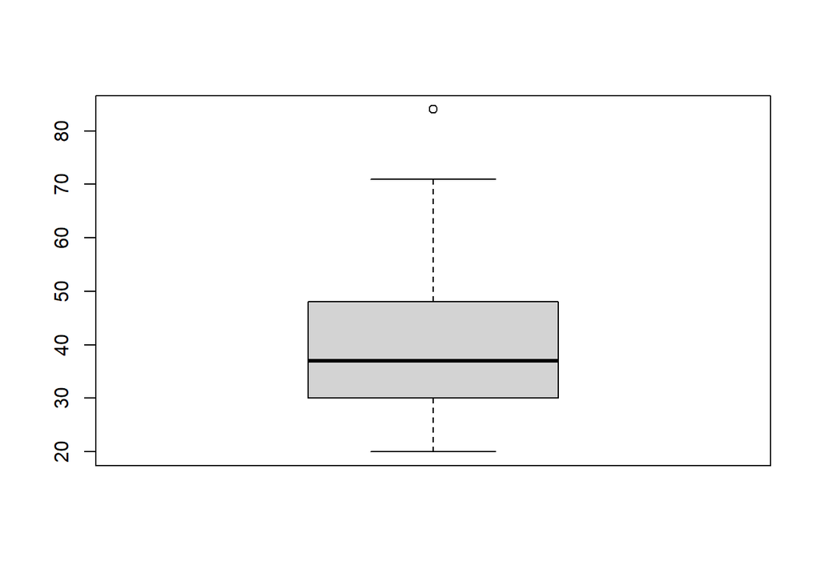

```r
outliers <- boxplot(corrupcion$CPI2016)$out #valores atipicos
```

```r
outliers
```

```
## [1] 84
```

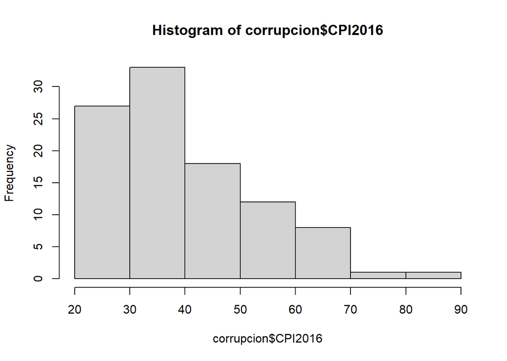

```r
#Gráficos
hist(corrupcion$CPI2016)
```

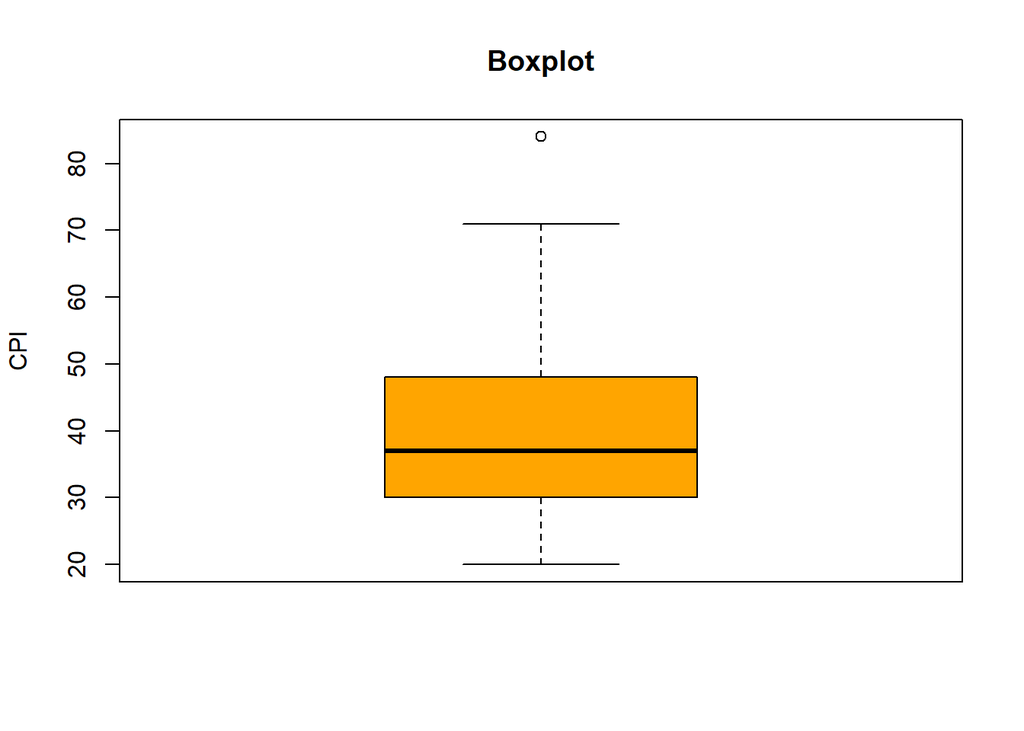

```r
boxplot(corrupcion$CPI2016, main="Boxplot", col="Orange", ylab="CPI")
```

# VARIABLE INDEPENDIENTES:

# Variable IDH - Brigitte Córdova

```r
summary(corrupcion$idh)
```

```
##    Min. 1st Qu.  Median    Mean 3rd Qu.    Max.
##  0.3980  0.5853  0.7275  0.6995  0.8065  0.9330
```

```r
#Desviación
sd(corrupcion$idh)
```

```
## [1] 0.1342499
```

```r
#varianza
var(corrupcion$idh)
```

```
## [1] 0.01802304
```

```r
rango=max(corrupcion$idh)-min(corrupcion$idh) #Rango
rango
```

```
## [1] 0.535
```

```r
quantile(corrupcion$idh) #cuartiles
```

```
##      0%     25%     50%     75%    100%
## 0.39800 0.58525 0.72750 0.80650 0.93300
```

```r
IQR=IQR(corrupcion$idh) #Rango Intercuartil
IQR
```

```
## [1] 0.22125
```

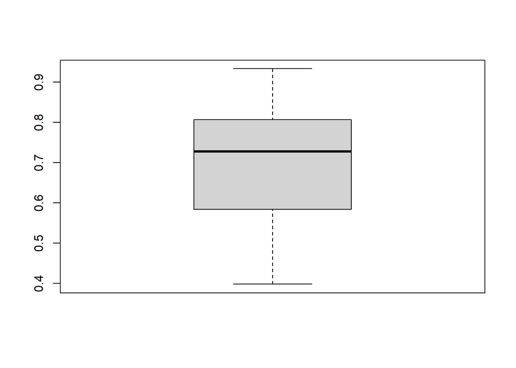

```r
outliers <- boxplot(corrupcion$idh)$out #valores atipicos
```

```r
outliers
```

```
## numeric(0)
```

```r
#Asimetría y kurtosis
skewness(corrupcion$idh)
```

```
## [1] -0.462307
```

```r
kurtosis(corrupcion$idh)
```

```
## [1] -0.8807632
```

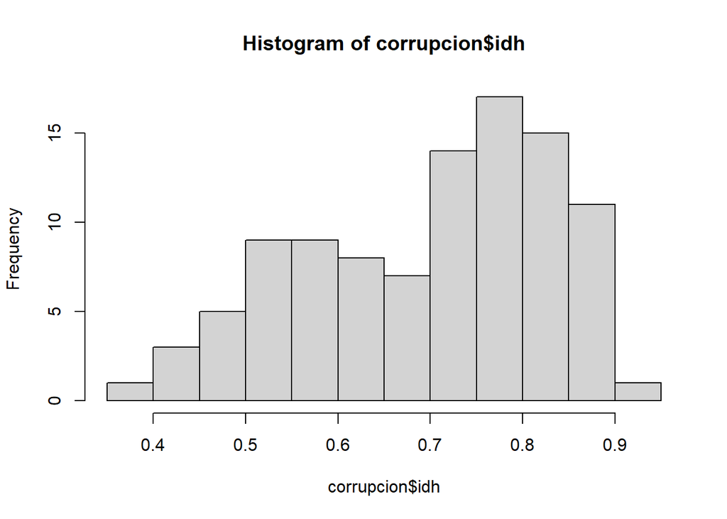

```r
#GRÁFICOS
hist(corrupcion$idh)
```

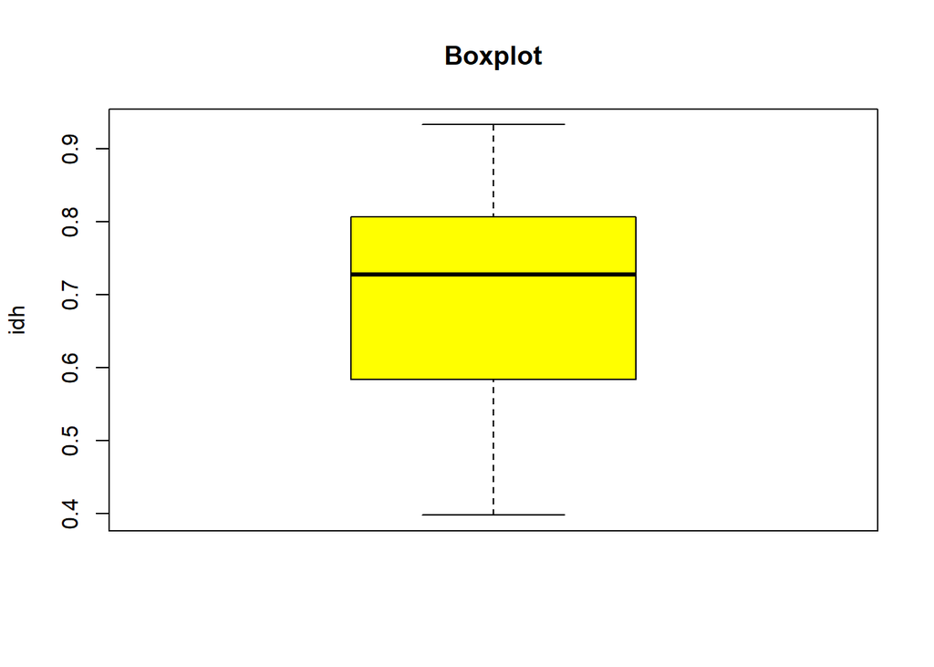

```r
boxplot(corrupcion$idh, main="Boxplot", col="Yellow", ylab="idh")
```

# Variable Rule of Law - Brigitte Córdova

```r
#Summary
str(corrupcion$`Rule of law`)
```

```
##  num [1:100] -0.857 -0.394 -0.119 -0.52 0.456 ...
```

```r
summary(corrupcion$`Rule of law`)
```

```
##    Min. 1st Qu.  Median    Mean 3rd Qu.    Max.
## -1.4602 -0.7137 -0.2060 -0.1528  0.3614  1.8252
```

```r
#medidas de dispersión
sd(corrupcion$`Rule of law`)
```

```
## [1] 0.6880014
```

```r
var(corrupcion$`Rule of law`)
```

```
## [1] 0.4733459
```

```r
rango=max(corrupcion$`Rule of law`)-min(corrupcion$`Rule of law`) #Rango
rango
```

```
## [1] 3.28548
```

```r
quantile(corrupcion$`Rule of law`) #cuartiles
```

```
##         0%        25%        50%        75%       100%
## -1.4602370 -0.7137455 -0.2059573  0.3614082  1.8252430
```

```r
IQR=IQR(corrupcion$`Rule of law`) #Rango Intercuartil
IQR
```

```
## [1] 1.075154
```

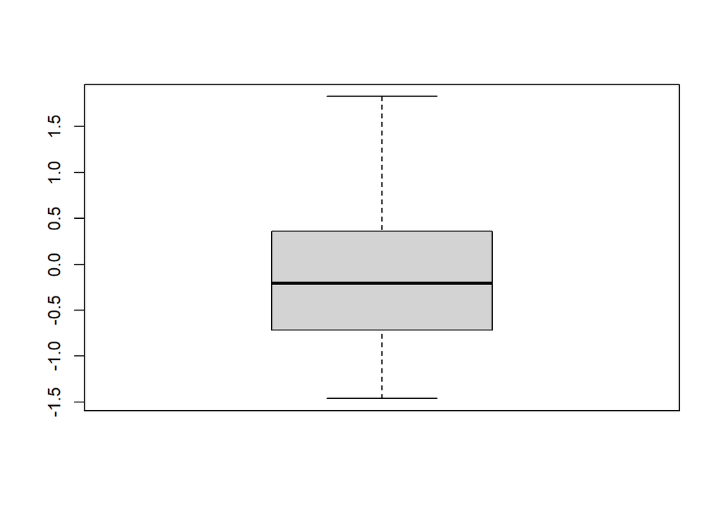

```r
outliers <- boxplot(corrupcion$`Rule of law`) $out #valores atipicos
```

```r
outliers
```

```
## numeric(0)
```

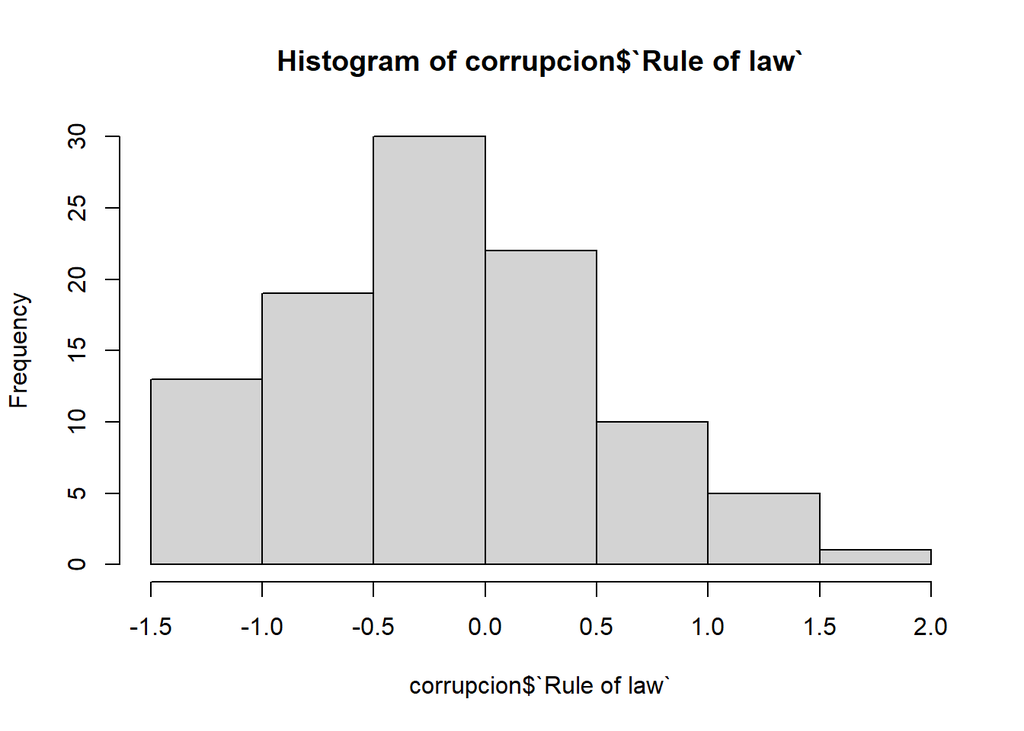

```r
#Gráficos
hist(corrupcion$`Rule of law`)
```

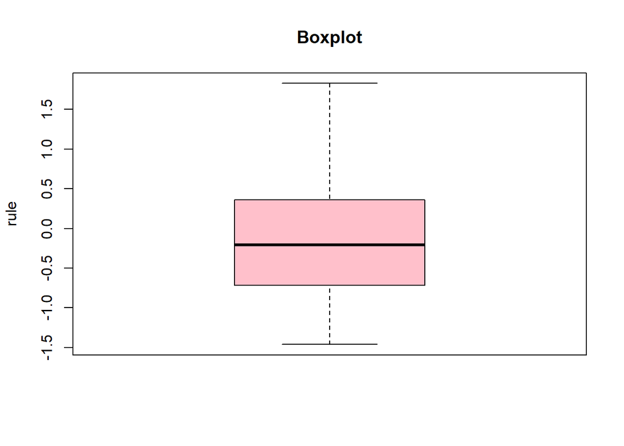

```r
boxplot(corrupcion$`Rule of law`, main="Boxplot", col="Pink", ylab="rule")
```

# Variable Desempleo - Luis Torres

```r
#variables Des2016
summary(corrupcion$Des2016)
```

```
##    Min. 1st Qu.  Median    Mean 3rd Qu.    Max.
##   0.150   3.426   5.723   7.591  10.361  26.551
```

```r
#dispersion
sd(corrupcion$Des2016)
```

```
## [1] 6.004603
```

```r
var(corrupcion$Des2016)
```

```
## [1] 36.05526
```

```r
skewness(corrupcion$Des2016)
```

```
## [1] 1.325912
```

```r
kurtosis(corrupcion$Des2016)
```

```
## [1] 1.273903
```

```r
rango=max(corrupcion$Des2016)-min(corrupcion$Des2016)
rango
```

```
## [1] 26.401
```

```r
quantile(corrupcion$Des2016)
```

```
##       0%      25%      50%      75%     100%
##  0.15000  3.42575  5.72250 10.36125 26.55100
```

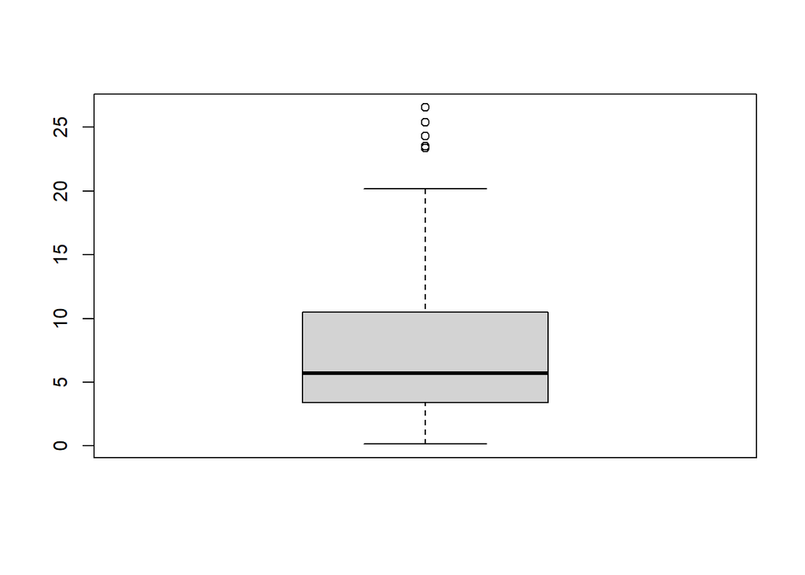

```r
outliers <- boxplot(corrupcion$Des2016)$out
```

```r
outliers
```

```
## [1] 25.408 23.539 24.300 23.352 26.551
```

```r
IQR=IQR(corrupcion$Des2016)
IQR
```

```
## [1] 6.9355
```

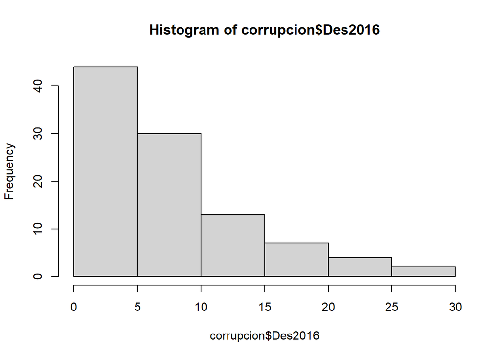

```r
#graficos
hist(corrupcion$Des2016)
```

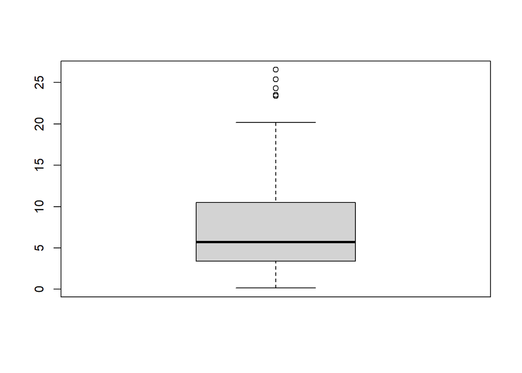

```r
boxplot(corrupcion$Des2016)
```

# Variable Efectividad - Luis Torres

```r
#variables
summary(corrupcion$Efec2016)
```

```
##     Min.  1st Qu.   Median     Mean  3rd Qu.     Max.
## -2.07849 -0.64210 -0.10211 -0.08941  0.34524  2.20625
```

```r
#dispersion
sd(corrupcion$Efec2016)
```

```
## [1] 0.7268492
```

```r
var(corrupcion$Efec2016)
```

```
## [1] 0.5283098
```

```r
skewness(corrupcion$Efec2016)
```

```
## [1] 0.2129769
```

```r
kurtosis(corrupcion$Efec2016)
```

```
## [1] 0.1580467
```

```r
rango=max(corrupcion$Efec2016)-min(corrupcion$Efec2016)
rango
```

```
## [1] 4.284737
```

```r
quantile(corrupcion$Efec2016)
```

```
##         0%        25%        50%        75%       100%
## -2.0784920 -0.6421010 -0.1021082  0.3452419  2.2062450
```

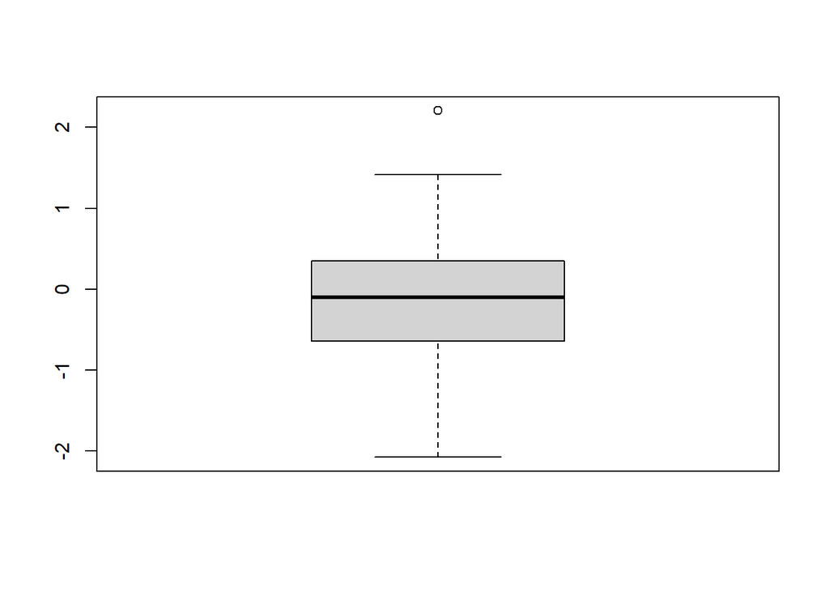

```r
outliers <- boxplot(corrupcion$Efec2016)$out
```

```r
outliers
```

```
## [1] 2.206245
```

```r
IQR=IQR(corrupcion$Efec2016)
IQR
```

```
## [1] 0.9873429
```

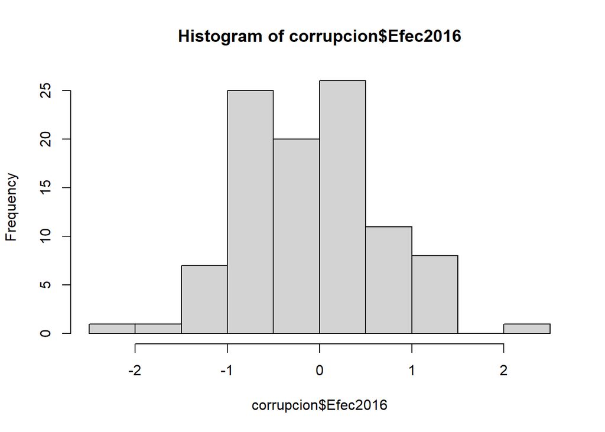

```r
#graficos
hist(corrupcion$Efec2016)
```

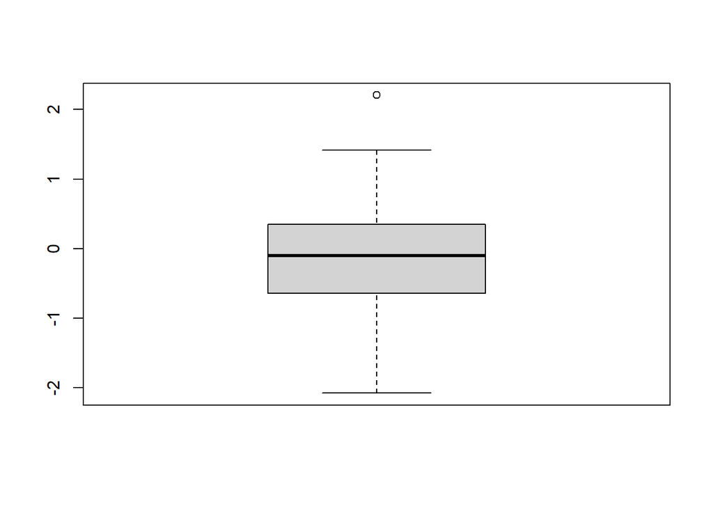

```r
boxplot(corrupcion$Efec2016)
```

#Analísis univariado de la variable account - Isaura Sánchez.

```r
corrupcion$Account2016=as.numeric(corrupcion$Account2016)
#medidas de tendencia central
summary(corrupcion$Account2016)
```

```
##     Min.  1st Qu.   Median     Mean  3rd Qu.     Max.
## -1.72922 -0.70400 -0.06578 -0.12195  0.46107  1.20798
```

```r
#medidas de dispersión
sd(corrupcion$Account2016) #desviación
```

```
## [1] 0.7841114
```

```r
var(corrupcion$Account2016) #varianza
```

```
## [1] 0.6148307
```

```r
skewness(corrupcion$Account2016) #asimetría
```

```
## [1] -0.1728429
```

```r
kurtosis(corrupcion$Account2016) #curtosis
```

```
## [1] -0.93963
```

```r
rango=max(corrupcion$Account2016)-min(corrupcion$Account2016) #Rango
rango
```

```
## [1] 2.937201
```

```r
quantile(corrupcion$Account2016) #cuartiles
```

```
##          0%         25%         50%         75%        100%
## -1.72921700 -0.70399525 -0.06577825  0.46106542  1.20798400
```

```r
IQR=IQR(corrupcion$Account2016) #Rango Intercuartil
IQR
```

```
## [1] 1.165061
```

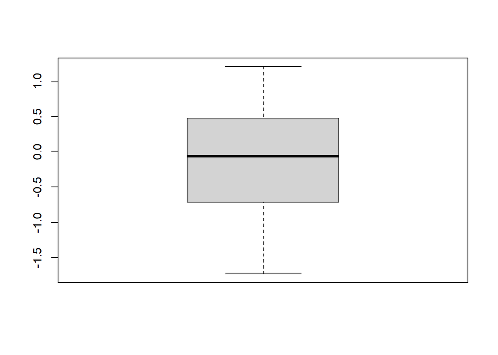

```r
outliers <- boxplot(corrupcion$Account2016)$out #valores atipicos
```

```r
outliers
```

```
## numeric(0)
```

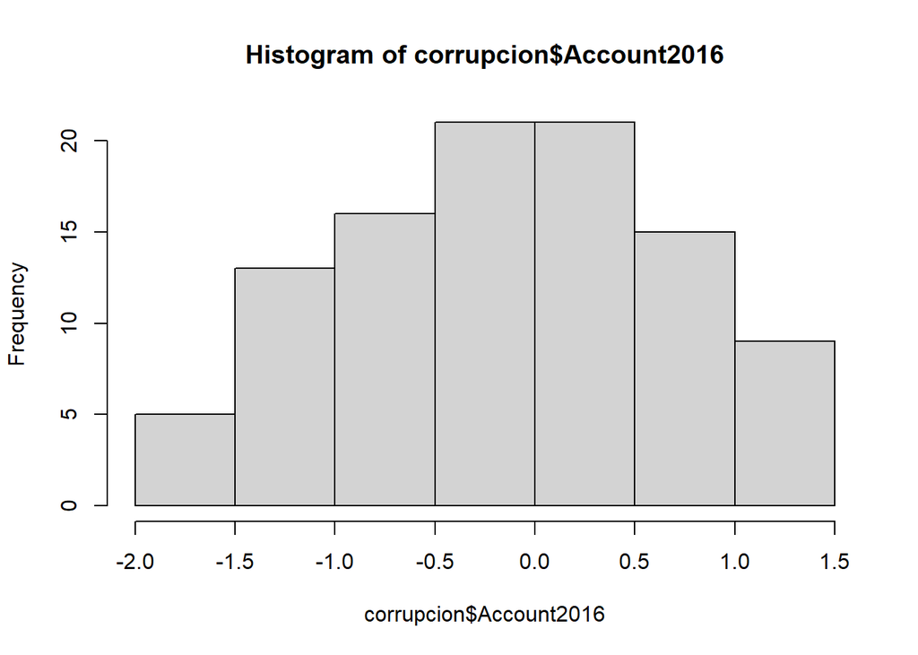

```r
#GRÁFICOS
hist(corrupcion$Account2016)
```

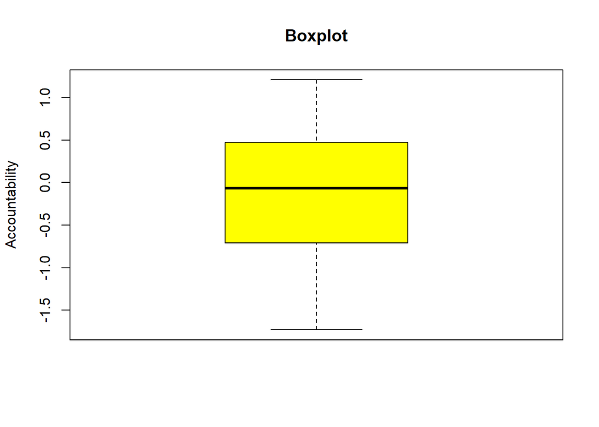

```r
boxplot(corrupcion$Account2016, main="Boxplot", col="Yellow", ylab="Accountability")
```

#Analisis univariado de la variable GINI - Isaura Sánchez

```r
corrupcion$GINI2016=as.numeric(corrupcion$GINI2016)
#medidas de tendencia central
summary(corrupcion$GINI2016)
```

```
##    Min. 1st Qu.  Median    Mean 3rd Qu.    Max.
##   25.40   35.38   38.00   39.86   44.45   63.00
```

```r
#medidas de dispersión
sd(corrupcion$GINI2016)
```

```
## [1] 7.311644
```

```r
var(corrupcion$GINI2016)
```

```
## [1] 53.46013
```

```r
skewness(corrupcion$GINI2016)
```

```
## [1] 0.6674865
```

```r
kurtosis(corrupcion$GINI2016)
```

```
## [1] 0.3124113
```

```r
rango=max(corrupcion$GINI2016)-min(corrupcion$GINI2016) #Rango
rango
```

```
## [1] 37.6
```

```r
quantile(corrupcion$GINI2016) #cuartiles
```

```
##     0%    25%    50%    75%   100%
## 25.400 35.375 38.000 44.450 63.000
```

```r
IQR=IQR(corrupcion$GINI2016) #Rango Intercuartil
IQR
```

```
## [1] 9.075
```

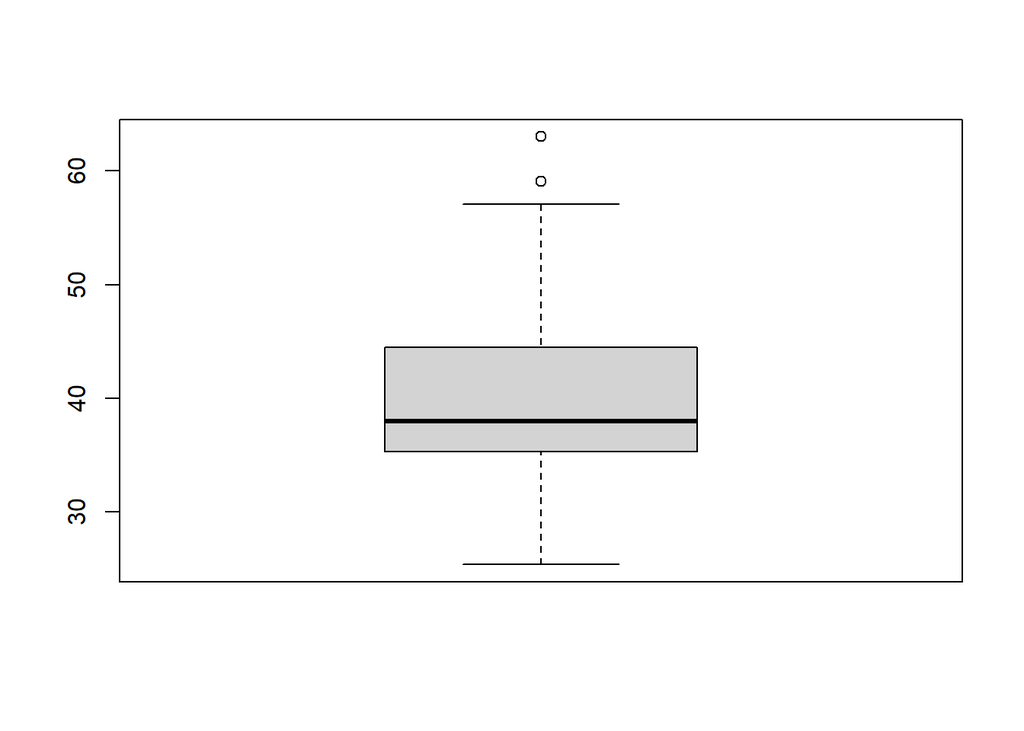

```r
outliers <- boxplot(corrupcion$GINI2016)$out #valores atipicos
```

```r
outliers
```

```
## [1] 59.1 63.0
```

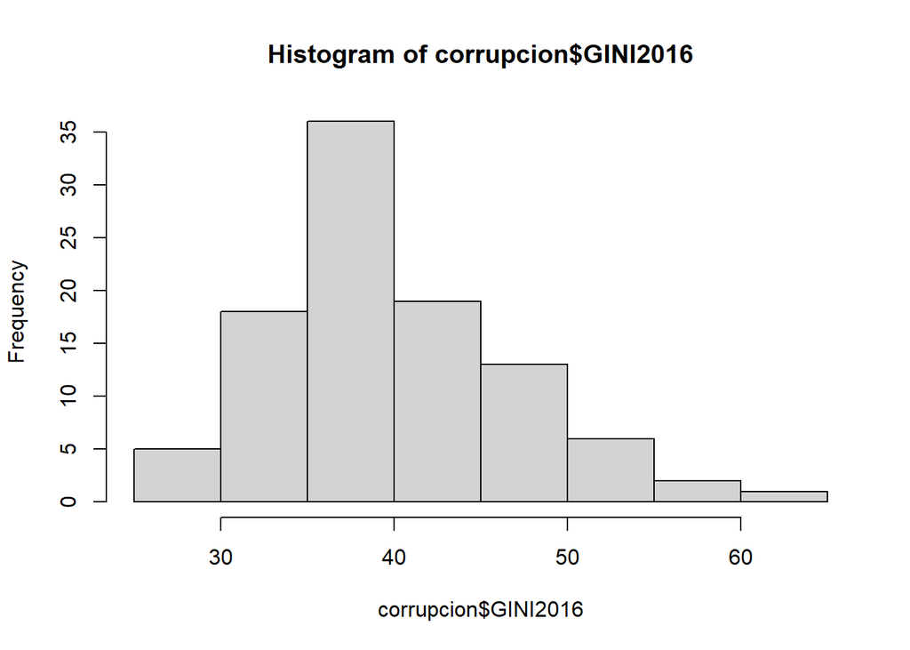

```r
#Gráficos
hist(corrupcion$GINI2016)
```

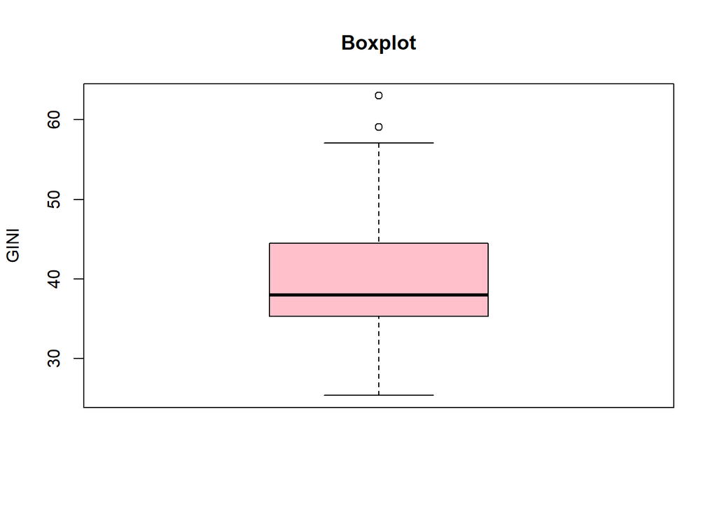

```r
boxplot(corrupcion$GINI2016, main="Boxplot", col="Pink", ylab="GINI")
```

# Variable Gasto Actual en Salud - Mayra Vargas

```r
#Estadísticos descriptivos
summary(corrupcion$CHE)
```

```
##    Min. 1st Qu.  Median    Mean 3rd Qu.    Max.
##   2.312   4.464   6.247   6.185   7.668   9.952
```

```r
#Estadísticos de dispersión
skewness(corrupcion$CHE)
```

```
## [1] 0.04373928
```

```r
kurtosis(corrupcion$CHE)
```

```
## [1] -1.089806
```

```r
# desviación estándar y varianza
sd(corrupcion$CHE)
```

```
## [1] 1.938588
```

```r
var(corrupcion$CHE)
```

```
## [1] 3.758124
```

```r
rango=max(corrupcion$CHE)-min(corrupcion$CHE) #Para obtener el rango
rango
```

```
## [1] 7.640186
```

```r
quantile(corrupcion$CHE) #obtenemos los cuartiles
```

```
##       0%      25%      50%      75%     100%
## 2.311780 4.463795 6.246690 7.668355 9.951966
```

```r
IQR=IQR(corrupcion$CHE) #Rango Intercuartil
IQR
```

```
## [1] 3.204561
```

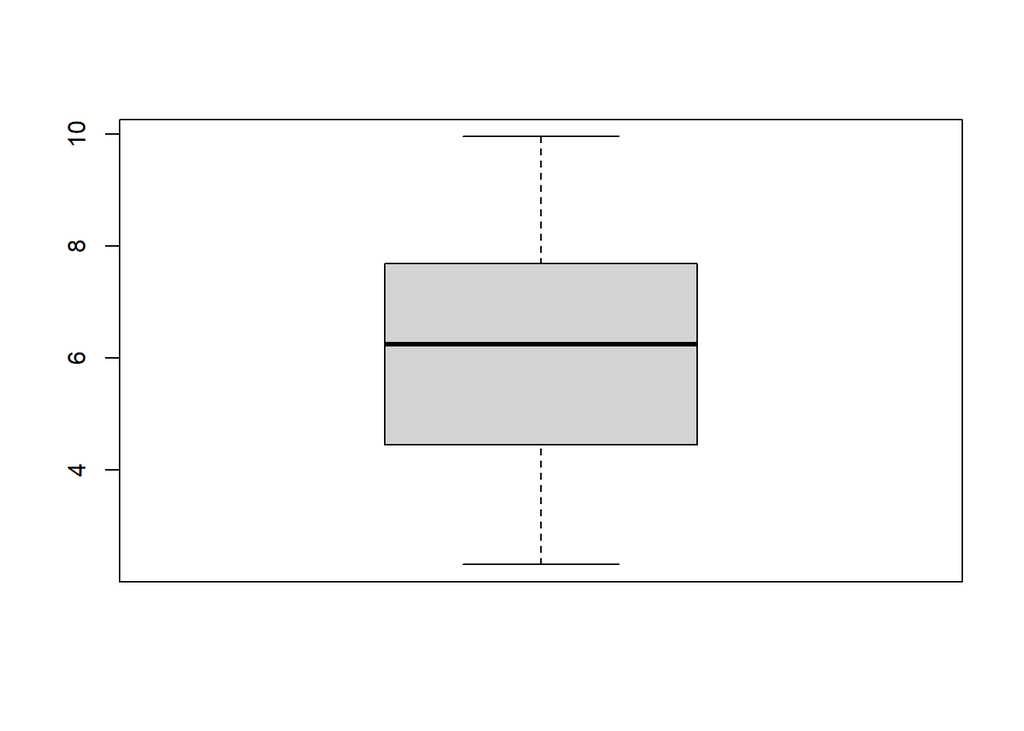

```r
outliers <- boxplot(corrupcion$CHE)$out #valores atipicos
```

```r
outliers
```

```
## numeric(0)
```

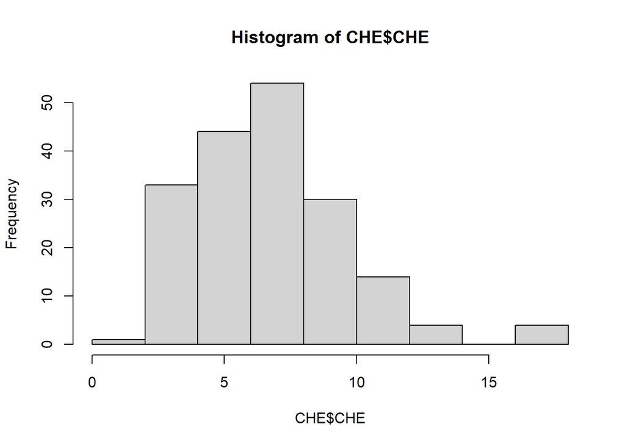

```r
#Gráficas:
hist(CHE$CHE)
```

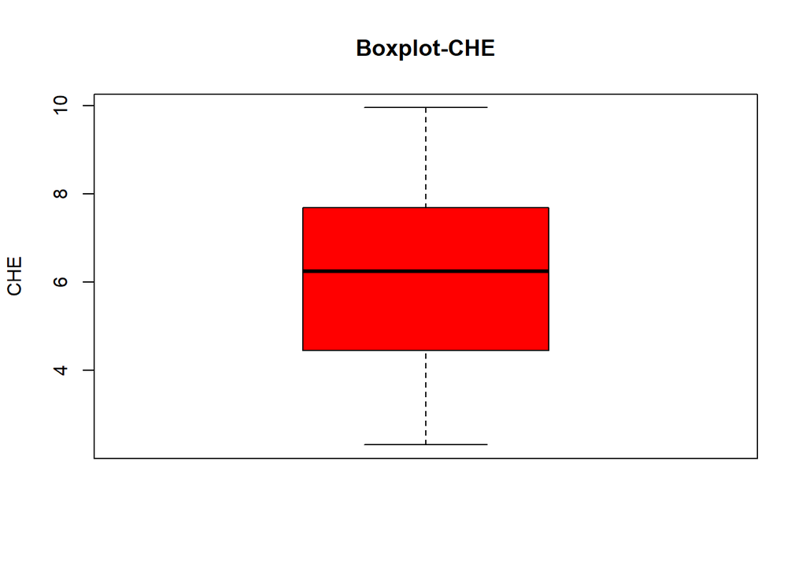

```r
boxplot(corrupcion$CHE, main="Boxplot-CHE", col="Red", ylab="CHE")
```

# Variable de Tasa de alfabetización de adultos

```r
#Estadísticos Descriptivos
summary(corrupcion$TasaAlfab)
```

```
##    Min. 1st Qu.  Median    Mean 3rd Qu.    Max.
##   30.41   77.77   94.20   85.50   97.84   99.89
```

```r
#Estadísticos de dispersión
skewness(corrupcion$TasaAlfab)
```

```
## [1] -1.373262
```

```r
kurtosis(corrupcion$TasaAlfab)
```

```
## [1] 0.9624922
```

```r
#desviación y varianza
sd(corrupcion$TasaAlfab)
```

```
## [1] 17.05116
```

```r
var(corrupcion$TasaAlfab)
```

```
## [1] 290.742
```

```r
rango=max(corrupcion$TasaAlfab)-min(corrupcion$CHE) #Para obtener el rango
rango
```

```
## [1] 97.5796
```

```r
quantile(corrupcion$TasaAlfab) #obtenemos los cuartiles
```

```
##       0%      25%      50%      75%     100%
## 30.40826 77.77027 94.20272 97.83930 99.89138
```

```r
IQR=IQR(corrupcion$TasaAlfab) #Rango Intercuartil
IQR
```

```
## [1] 20.06904
```

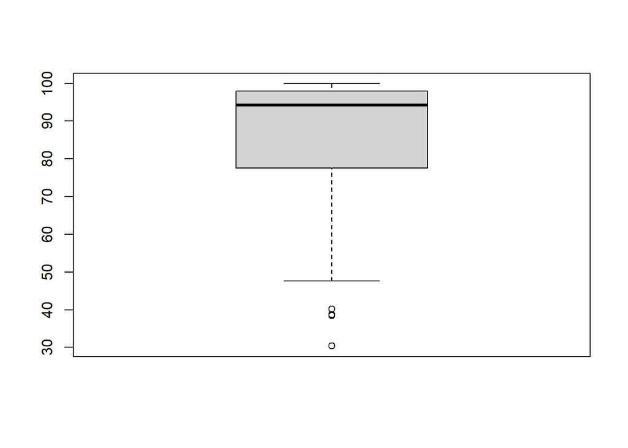

```r
outliers <- boxplot(corrupcion$TasaAlfab)$out #valores atipicos
```

```r
outliers
```

```
## [1] 38.44714 40.17137 30.40826 38.70194
```

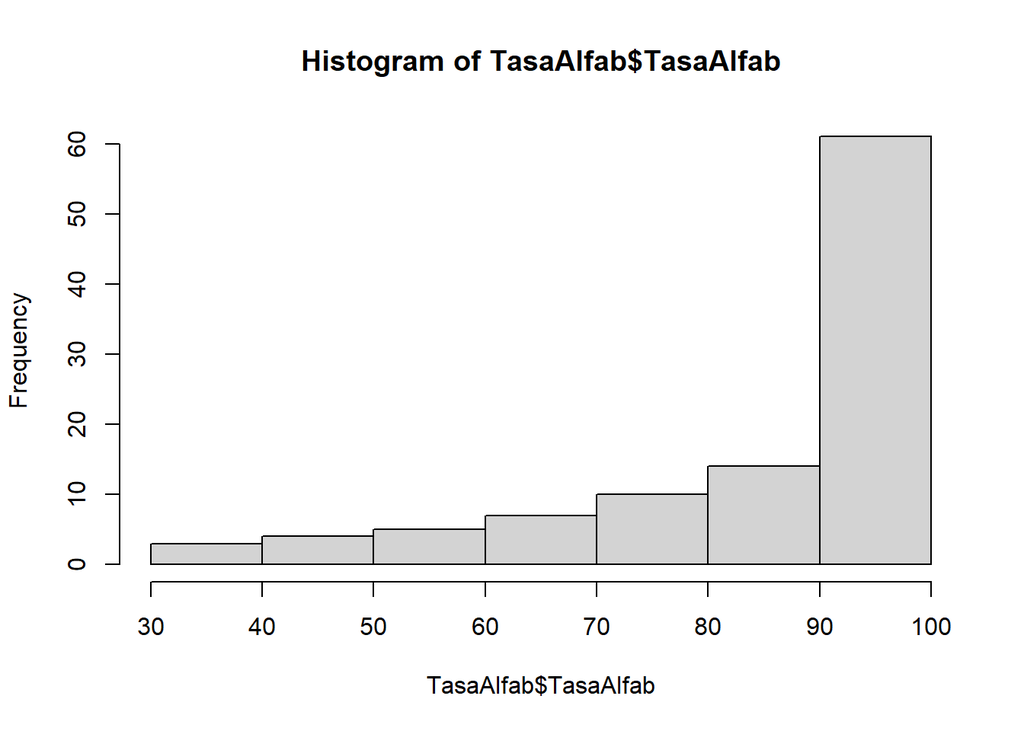

```r
#Gráficas
hist(TasaAlfab$TasaAlfab)
```

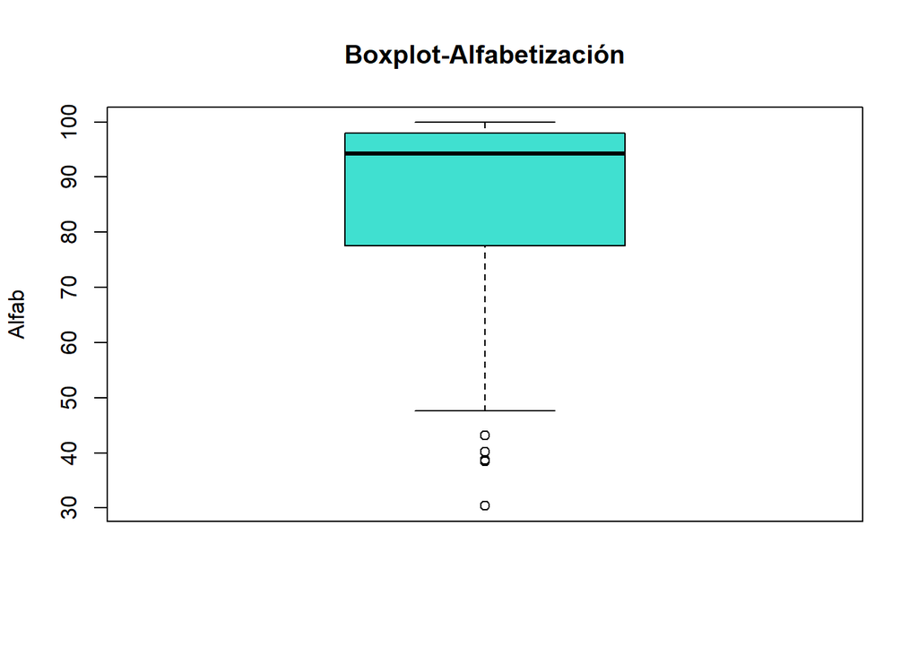

```r
boxplot(TasaAlfab$TasaAlfab, main="Boxplot-Alfabetización", col="Turquoise", ylab="Alfab")
```

# Modelo 1: CPI - GINI (Isaura Sánchez)

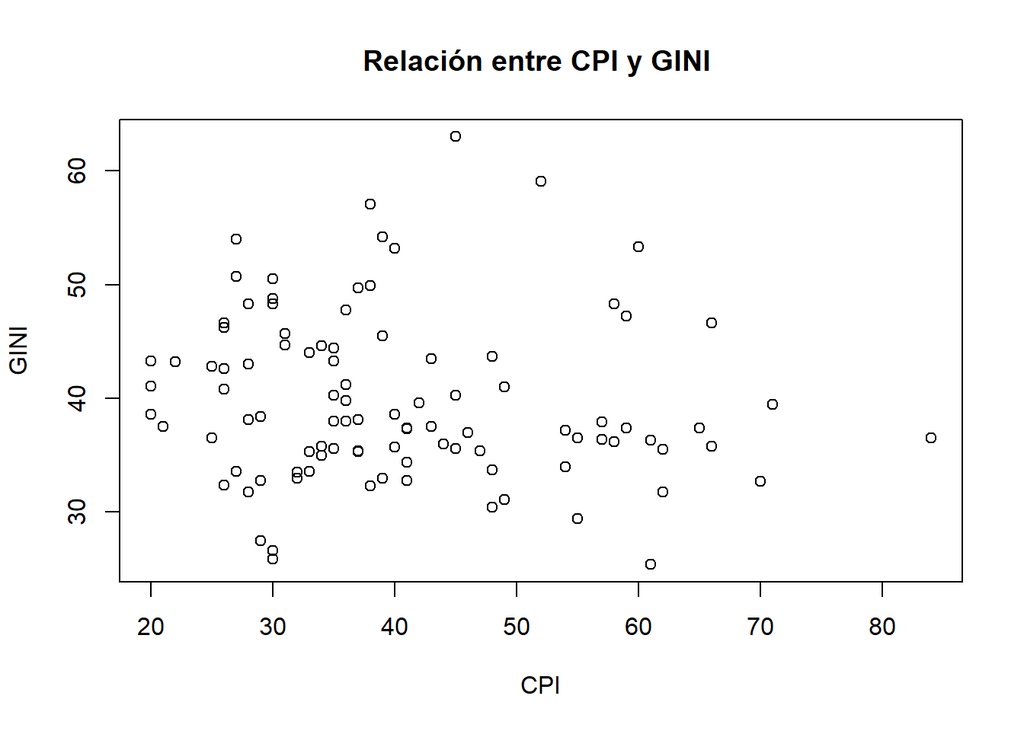

```r
plot(corrupcion$CPI2016, corrupcion$GINI2016,
     main="Relación entre CPI y GINI ",
     xlab="CPI",
     ylab="GINI")
```

```r
cor.test(corrupcion$CPI2016, corrupcion$GINI2016)
```

```
##
##  Pearson's product-moment correlation
##
## data:  corrupcion$CPI2016 and corrupcion$GINI2016
## t = -1.2449, df = 98, p-value = 0.2161
## alternative hypothesis: true correlation is not equal to 0
## 95 percent confidence interval:
##  -0.31351018  0.07344243
## sample estimates:
##        cor
## -0.1247756
```

```r
modelo1=lm(CPI2016~GINI2016,data=corrupcion)
summary(modelo1)
```

```
##
## Call:
## lm(formula = CPI2016 ~ GINI2016, data = corrupcion)
##
## Residuals:
##     Min      1Q  Median      3Q     Max
## -20.698  -9.887  -3.392   7.062  42.824
##
## Coefficients:
##             Estimate Std. Error t value Pr(>|t|)
## (Intercept)  49.4866     7.4112   6.677 1.48e-09 ***
## GINI2016     -0.2277     0.1829  -1.245    0.216
## ---
## Signif. codes:  0 '***' 0.001 '**' 0.01 '*' 0.05 '.' 0.1 ' ' 1
##
## Residual standard error: 13.31 on 98 degrees of freedom
## Multiple R-squared:  0.01557,    Adjusted R-squared:  0.005524
## F-statistic:  1.55 on 1 and 98 DF,  p-value: 0.2161
```

# Modelo 2: CPI - Accountability (Isaura Sánchez)

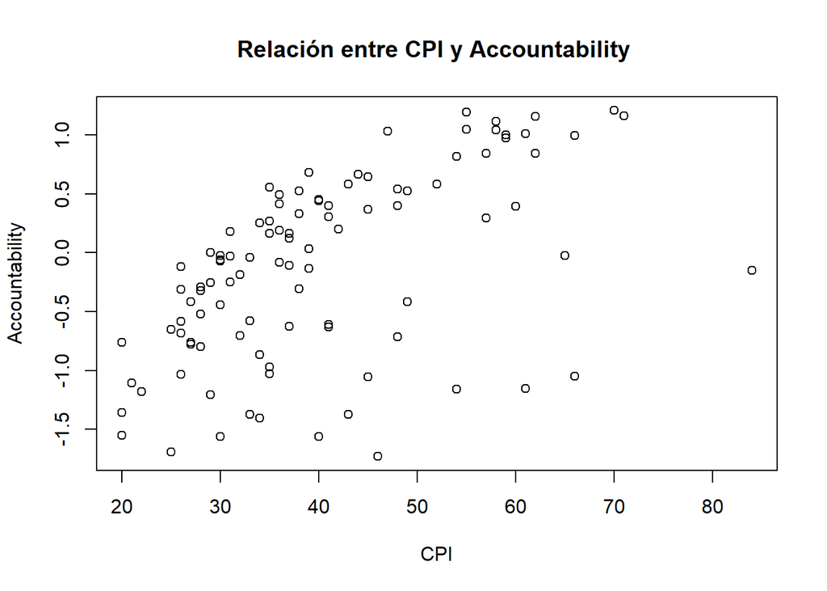

```r
plot(corrupcion$CPI2016, corrupcion$Account2016,
     main="Relación entre CPI y Accountability ",
     xlab="CPI",
     ylab="Accountability")
```

```r
cor.test(corrupcion$CPI2016, corrupcion$Account2016)
```

```
##
##  Pearson's product-moment correlation
##
## data:  corrupcion$CPI2016 and corrupcion$Account2016
## t = 6.3379, df = 98, p-value = 7.134e-09
## alternative hypothesis: true correlation is not equal to 0
## 95 percent confidence interval:
##  0.3833744 0.6651633
## sample estimates:
##       cor
## 0.5391905
```

```r
modelo2=lm(CPI2016~Account2016,data=corrupcion)
summary(modelo2)
```

```
##
## Call:
## lm(formula = CPI2016 ~ Account2016, data = corrupcion)
##
## Residuals:
##     Min      1Q  Median      3Q     Max
## -14.561  -8.709  -3.263   5.269  43.852
##
## Coefficients:
##             Estimate Std. Error t value Pr(>|t|)
## (Intercept)   41.529      1.143  36.330  < 2e-16 ***
## Account2016    9.175      1.448   6.338 7.13e-09 ***
## ---
## Signif. codes:  0 '***' 0.001 '**' 0.01 '*' 0.05 '.' 0.1 ' ' 1
##
## Residual standard error: 11.29 on 98 degrees of freedom
## Multiple R-squared:  0.2907, Adjusted R-squared:  0.2835
## F-statistic: 40.17 on 1 and 98 DF,  p-value: 7.134e-09
```

# Modelo 3: CPI - IDH (Brigite Córdova)

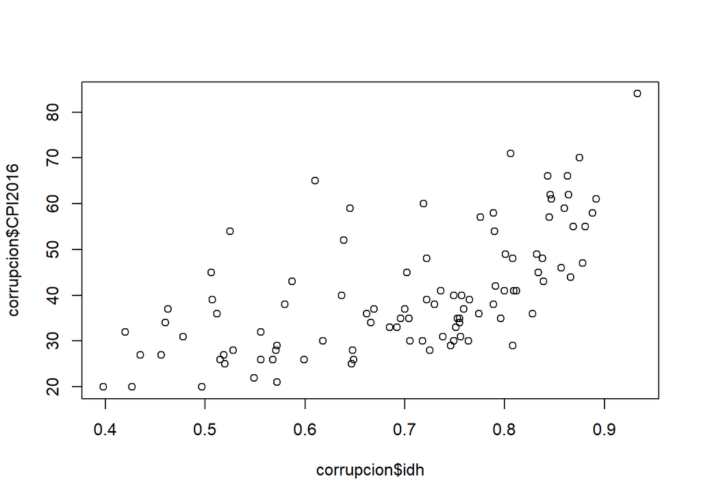

```r
#solicitamos un diagrama de dispersión
plot(corrupcion$CPI2016~corrupcion$idh)
```

```r
#solicitamos el test de correlacion
cor.test(corrupcion$CPI2016,corrupcion$idh)
```

```
##
##  Pearson's product-moment correlation
##
## data:  corrupcion$CPI2016 and corrupcion$idh
## t = 7.9059, df = 98, p-value = 4.026e-12
## alternative hypothesis: true correlation is not equal to 0
## 95 percent confidence interval:
##  0.4873526 0.7308692
## sample estimates:
##      cor
## 0.624035
```

```r
#solicitamos modelo de regresión simple
modelo3=lm(corrupcion$CPI2016~corrupcion$idh,data=corrupcion)

#realizo un summary para solicitar resultados
summary(modelo3)
```

```
##
## Call:
## lm(formula = corrupcion$CPI2016 ~ corrupcion$idh, data = corrupcion)
##
## Residuals:
##     Min      1Q  Median      3Q     Max
## -18.142  -6.986  -3.463   7.303  30.138
##
## Coefficients:
##                Estimate Std. Error t value Pr(>|t|)
## (Intercept)      -2.971      5.586  -0.532    0.596
## corrupcion$idh   62.020      7.845   7.906 4.03e-12 ***
## ---
## Signif. codes:  0 '***' 0.001 '**' 0.01 '*' 0.05 '.' 0.1 ' ' 1
##
## Residual standard error: 10.48 on 98 degrees of freedom
## Multiple R-squared:  0.3894, Adjusted R-squared:  0.3832
## F-statistic:  62.5 on 1 and 98 DF,  p-value: 4.026e-12
```

```r
#identificamos los coeficientes y construimos la ecuación
modelo3$coefficients
```

```
##    (Intercept) corrupcion$idh
##      -2.970526      62.020024
```

# Modelo 4: CPI - Rule of Law (Brigite Córdova)

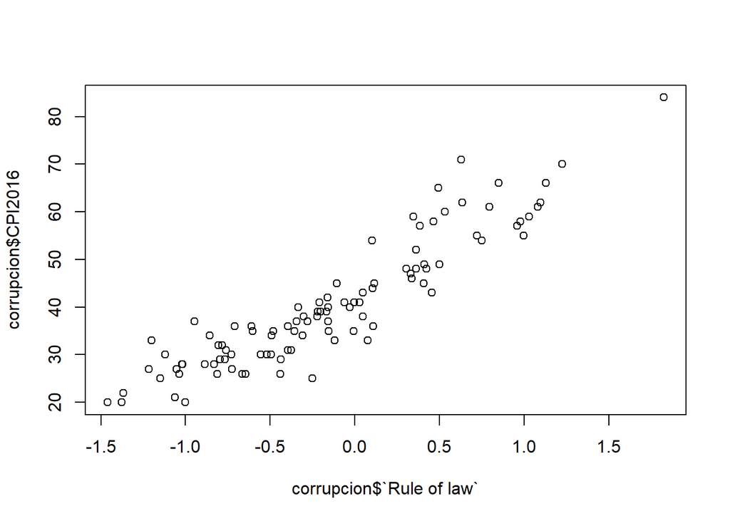

```r
#solicitamos un diagrama de dispersión
plot(corrupcion$CPI2016~corrupcion$`Rule of law`)
```

```r
#solicitamos el test de correlacion
cor.test(corrupcion$CPI2016,corrupcion$`Rule of law`)
```

```
##
##  Pearson's product-moment correlation
##
## data:  corrupcion$CPI2016 and corrupcion$`Rule of law`
## t = 23.234, df = 98, p-value < 2.2e-16
## alternative hypothesis: true correlation is not equal to 0
## 95 percent confidence interval:
##  0.8831375 0.9455339
## sample estimates:
##       cor
## 0.9199732
```

```r
#solicitamos modelo de regresión simple
modelo4=lm(corrupcion$CPI2016~corrupcion$`Rule of law`,data=corrupcion)

#realizo un summary para solicitar resultados
summary(modelo4)
```

```
##
## Call:
## lm(formula = corrupcion$CPI2016 ~ corrupcion$`Rule of law`, data = corrupcion)
##
## Residuals:
##      Min       1Q   Median       3Q      Max
## -13.6543  -3.1587  -0.4865   2.8522  16.6175
##
## Coefficients:
##                          Estimate Std. Error t value Pr(>|t|)
## (Intercept)               43.1356     0.5386   80.09   <2e-16 ***
## corrupcion$`Rule of law`  17.8411     0.7679   23.23   <2e-16 ***
## ---
## Signif. codes:  0 '***' 0.001 '**' 0.01 '*' 0.05 '.' 0.1 ' ' 1
##
## Residual standard error: 5.257 on 98 degrees of freedom
## Multiple R-squared:  0.8464, Adjusted R-squared:  0.8448
## F-statistic: 539.8 on 1 and 98 DF,  p-value: < 2.2e-16
```

```r
#identificamos los coeficientes y construimos la ecuación
modelo4$coefficients
```

```
##              (Intercept) corrupcion$`Rule of law`
##                 43.13559                 17.84115
```